# Analyzing Healthcare Provider Shortage - Part 3/4

> - 👟 Ready To Run!
> - 🔬 Data Science
> - 🚀 Data Exploration and Cleaning
> - 📈 Statistics & Graphing
> - ⚕️ Healthcare

> **Requirements**
> - 🗺️ Living Atlas configured

In this part of the study, we will explore shortage of Mental Healthcare Providers and OB-GYN Providers. We will study:

- The distribution of providers across all states to identify which states have highest shortage and
- For states with most shortage, study shortage at the county level to understand which counties are suffering the most.

# In this section, we will:

- **Explore Mental Healthcare Providers**
  - Study how Mental Healthcare Providers vary by Population Density accross all states
  - Identify state with highest people to provider ratio
  - Explore the state with highest ratio to understand how providers vary across different counties for that state
- **Explore OBGYN Healthcare Providers**
  - Study how OBGYN Healthcare Providers vary by population of mothers accross all states
  - Identify state with highest mothers to provider ratio
  - Explore the state with highest ratio to understand how providers vary across different counties for that state

# Part 3: Provider Shortage - Mental Health and OB-GYN Providers

```python
# Import Libraries
from IPython.display import display

# Import arcgis
import arcgis
from arcgis.gis import GIS
from arcgis.features import FeatureLayer
from arcgis.mapping import WebMap

# Import libraries for data exploration
import pandas as pd
pd.set_option('display.max_columns', 500)
import numpy as np

# Import plotting libraries
%matplotlib inline
import matplotlib.pyplot as plt
import seaborn as sns

# Import library for time
import time
```

```python
# Create a GIS connection
gis = GIS("home")
```

## Get Data Layers

### Get Provider Data

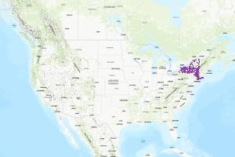

[**provider_data_geocoded_7_30**](https://datascienceqa.esri.com/portal/home/item.html?id=b5204d47ee80440395eb7e567b5a2399)  
Geocoded healthcare provider point data of 5.8M providers in US.

[figure not shown]

Feature Layer Collection by portaladmin  
Last Modified: June 04, 2020  
0 comments, 1 views

```python
# Search the feature layer
data_groups = gis.groups.search('"ArcGIS Sample Notebooks Data" owner:esri_notebook',
                                outside_org=True)
group_query = f"group: {data_groups[0].id}" if data_groups else ""
provider_data_item = gis.content.search(f'provider_data_geocoded_7_30 {group_query}',
                                      item_type = "Feature Service",
                                      outside_org=True)[0]
provider_data_item
```

```python
# Get the layer needed for analysis
provider_data_layer = provider_data_item.layers[0]
provider_data_layer
```

```
<FeatureLayer url:"https://datascienceqa.esri.com/server/rest/services/Hosted/provider_data_geocoded_7_30/FeatureServer/0">
```

```python
# Look at the first 5 fields and their data types
for f in provider_data_layer.properties.fields[:5]:
    print(f['name'], "{0:>35}".format(f['type']))
```

```
objectid                    esriFieldTypeOID
user_npi                 esriFieldTypeDouble
user_entity_type                 esriFieldTypeString
user_address                 esriFieldTypeString
user_address2                 esriFieldTypeString
```

### Get Demographics Data

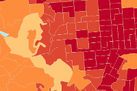

[**2020 USA Population Density**](https://geosaurus.maps.arcgis.com/home/item.html?id=b9095ebdf5e8442588ab3f269dc7ee5e)  
This layer shows the population density in the United States in 2020 in persons per square mile in a multiscale map by country, state, county, ZIP Code, tract, and block group. ArcGIS Online subscription required.

[figure not shown]

Map Image Layer by esri  
Last Modified: June 29, 2020  
0 comments, 7,118 views

```python
# Search for and get Population data layer
popdensity = gis.content.get('b9095ebdf5e8442588ab3f269dc7ee5e') #2020 layer
popdensity
```

```python
# Check first 5 layers in population Density
popdensity.layers[:5]
```

```
[<FeatureLayer url:"https://demographics5.arcgis.com/arcgis/rest/services/USA_Demographics_and_Boundaries_2020/MapServer/0">,
 <FeatureLayer url:"https://demographics5.arcgis.com/arcgis/rest/services/USA_Demographics_and_Boundaries_2020/MapServer/1">,
 <FeatureLayer url:"https://demographics5.arcgis.com/arcgis/rest/services/USA_Demographics_and_Boundaries_2020/MapServer/2">,
 <FeatureLayer url:"https://demographics5.arcgis.com/arcgis/rest/services/USA_Demographics_and_Boundaries_2020/MapServer/3">,
 <FeatureLayer url:"https://demographics5.arcgis.com/arcgis/rest/services/USA_Demographics_and_Boundaries_2020/MapServer/4">]
```

```python
# Look at first few field names for county layer
county_layer = popdensity.layers[46]
print('FIELD NAME', "{0:>50}".format('FIELD ALIAS'))
for field in county_layer.properties.fields[:10]:
    print(field['name'], "{0:>50}".format(field['alias']))
```

```
FIELD NAME                                        FIELD ALIAS
OBJECTID                                           OBJECTID
Shape                                              Shape
ID                                                 ID
NAME                                               NAME
STATE_NAME                                         STATE_NAME
ST_ABBREV                                          ST_ABBREV
TOTPOP_CY                       2020 Total Population (Esri)
HHPOP_CY                   2020 Household Population (Esri)
FAMPOP_CY                      2020 Family Population (Esri)
GQPOP_CY              2020 Group Quarters Population (Esri)
```

```python
%%time

# Get specific attributes for Counties

county_layer = popdensity.layers[46]
county_df = pd.DataFrame()
out_fields = ['Shape','ST_ABBREV','NAME','ASIAN_CY','AMERIND_CY','AVGHHSZ_CY','AVGHINC_CY','BLACK_CY',
              'EDUCBASECY','HISPPOP_CY','MEDAGE_CY','MINORITYCY','OTHRACE_CY','PCI_CY','POPDENS_CY',
              'UNEMPRT_CY','WHITE_CY','SMCOLL_CY','ASSCDEG_CY','BACHDEG_CY','GRADDEG_CY','TOTPOP_CY']

offset = 0
while offset <= 3000:
    chunk_df = county_layer.query(out_fields=out_fields,return_all_records=False,
                                  result_offset=offset,result_record_count=750,as_df=True)
    county_df = pd.concat([chunk_df, county_df], ignore_index=True)

    offset += 750
```

```
Wall time: 27.3 s
```

```python
county_df.shape
```

```
(3142, 23)
```

## Mental Health

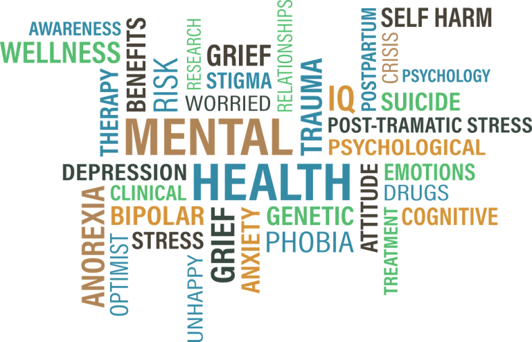

Image source: https://cuindependent.com/2019/03/08/opinion-mental-health-education/

- Nearly one in five people in the U.S. have some sort of mental health condition [[1]](https://www.samhsa.gov/data/sites/default/files/NSDUH-FFR1-2015/NSDUH-FFR1-2015/NSDUH-FFR1-2015.pdf).
- Adults living with serious mental illness die on average 25 years earlier than others [[2]](https://www.nami.org/Learn-More/Mental-Health-By-the-Numbers).
- Suicide is the 2nd leading cause of death for people aged 10–34 [[3]](https://www.nimh.nih.gov/health/statistics/suicide.shtml).

The table below shows a list of providers shortlisted as Mental healthcare providers. Provider Taxonomy codes were filtered using this [reference](http://www.wpc-edi.com/reference/codelists/healthcare/health-care-provider-taxonomy-code-set/).

| Taxonomy Code | Description | Taxonomy Code | Description |
| --- | --- | --- | --- |
| 207QG0300X | Family Medicine Geriatric Medicine | 273R00000X | Hospital Units Psychiatric Unit |
| 103T00000X | Psychologist | 103TA0400X | Psychologist Addiction (Substance Abuse Disorder) |
| 103TA0700X | Psychologist Adult Development & Aging | 103TC0700X | Psychologist Clinical |
| 103TC2200X | Psychologist Clinical Child & Adolescent | 103TB0200X | Psychologist Cognitive & Behavioral |
| 103TC1900X | Psychologist Counseling | 103TE1000X | Psychologist Educational |
| 103TE1100X | Psychologist Exercise & Sports | 103TF0000X | Psychologist Family |
| 103TF0200X | Psychologist Forensic | 103TP2701X | Psychologist Group Psychotherapy |
| 103TH0004X | Psychologist Health | 103TH0100X | Psychologist Health Service |
| 103TM1700X | Psychologist Men & Masculinity | 103TM1800X | Psychologist Mental Retardation |
| 103TP0016X | Psychologist Prescribing (Medical) | 103TP0814X | Psychologist Psychoanalysis |
| 103TP2700X | Psychologist Psychotherapy | 103TR0400X | Psychologist Rehabilitation |
| 103TS0200X | Psychologist School | 103TW0100X | Psychologist Women |
| 106E00000X | Assistant Behavior Analyst | 106S00000X | Technician |
| 103TC0700X | Psychologist Clinical | 2084A0401X | Physicians Psychiatry & Neurology |
| 2084P0802X | Physicians Addiction Psychiatry | 2084B0002X | Physicians Bariatric Medicine |
| 2084P0804X | Physicians Child & Adolescent Psychiatry | 2084N0600X | Physicians Clinical Neurophysiology |
| 2084D0003X | Physicians Diagnostic Neuroimaging | 2084F0202X | Physicians Forensic Psychiatry |
| 2084P0805X | Physicians Geriatric Psychiatry | 2084H0002X | Physicians Hospice & Palliative Medicine |
| 2084P0005X | Physicians Neurodevelopmental Disabilities | 2084N0400X | Physicians Neurology |
| 2084N0402X | Physicians Child Neurology | 2084N0008X | Physicians Neuromuscular Medicine |
| 2084P2900X | Physicians Pain Medicine | 2084P0800X | Physicians Psychiatry |
| 2084P0015X | Physicians Psychosomatic Medicine | 2084S0012X | Physicians Sleep Medicine |
| 2084S0010X | Physicians Sports Medicine | 2084V0102X | Physicians Vascular Neurology |
| 364SA2200X | Nurse/Assiatant Adult Health | 364SP0808X | Nurse/Assiatant Psychiatric/Mental Health |
| 364SP0809X | Nurse/Assiatant Mental Health Adult | 364SP0807X | Nurse/Assiatant Mental Health Child & Adolescent |
| 364SP0810X | Nurse/Assiatant Mental Health Child & Family | 364SP0811X | Nurse/Assiatant Mental Health Chronically Ill |
| 364SP0812X | Nurse/Assiatant Mental Health Community | 364SP0813X | Nurse/Assiatant Mental Health Geropsychiatric |
| 283Q00000X | Hospitals Psychiatric Hospital | 261QM0801X | Ambulatory Health Care Facilities/Clinic/Center Mental Health |
| 2084P0800X | Physician Psychiatry |  |  |

### Mental Healthcare Providers - Heat Map

Let's explore the distribution of mental health providers in the US using a heatmap.

[figure not shown]

```python
# Create a map
mental_map = gis.map('USA', 4)
mental_map
```

This map paints a grim picture of the availability of mental healthcare providers. There are states in every region with vast areas of no mental health providers or very few providers. To list, some of these states include:

- Midwest: The Dakotas, Montana, Wyoming, Colorado, Nebraska, Kansas
- South: Texas, New Mexico, Kansas, Louisiana, Mississippi, Alabama
- West: Nevada, Arizona, Oregon, Idaho, Alaska
- East: Maine, Vermont, Michigan

```python
# Add provider data to map
renderer = {"renderer": "autocast", #This tells python to use JS autocasting
            "type": "heatmap",
            "blurRadius":1,  # changes the size of the clusters
            "maxPixelIntensity":2,
            "minPixelIntensity":0,
            "field":None}
renderer["colorStops"] = [{"ratio":0,"color":[63, 40, 102, 0]},
                          {"ratio":0.25,"color":[167,97,170,179]},
                          {"ratio":0.50,"color":"#7b3ce9"},
                          {"ratio":0.75,"color":[222,102,0,179]},
                          {"ratio":1,"color":[244,204,0,179]}]
mental_map.add_layer(provider_data_layer,
               { "type": "FeatureLayer",
                 "renderer": renderer,
                "definition_expression" : "user_taxonomy_code_1 in ('2084P0800X','207QG0300X','273R00000X','103T00000X','103TA0400X','103TA0700X','103TC0700X','103TC2200X','103TB0200X','103TC1900X','103TE1000X','103TE1100X','103TF0000X','103TF0200X','103TP2701X','103TH0004X','103TH0100X','103TM1700X','103TM1800X','103TP0016X','103TP0814X','103TP2700X','103TR0400X','103TS0200X','103TW0100X','106E00000X','106S00000X','2084A0401X','2084P0802X','2084B0002X','2084P0804X','2084N0600X','2084D0003X','2084F0202X','2084P0805X','2084H0002X','2084P0005X','2084N0400X','2084N0402X','2084N0008X','2084P2900X','2084P0015X','2084S0012X','2084S0010X','2084V0102X','364SP0808X','364SP0809X','364SP0807X','364SP0810X','364SP0811X','364SP0812X','364SP0813X','283Q00000X','261QM0801X')"
               })
```

```python
# Add Legend
mental_map.legend = True
```

```python
# Save as a web map item
mental_map_item = mental_map.save({'title':'mental_heatmap',
                                    'snippet':'Heat map',
                                    'tags':'Mental Health',
                                    'typeKeywords':'WebMap'})
mental_map_item
```

[figure not shown]

[**mental_heatmap**](https://datascienceqa.esri.com/portal/home/item.html?id=1d2c72bd74024cd3846cd92e36d372a4)  
Heat map

[figure not shown]

Web Map by portaladmin  
Last Modified: August 11, 2020  
0 comments, 0 views

### Population to Providers Ratio by State

Let's find out the ratio of population to mental healthcare providers to understand which states have the least number of providers.

#### DataFrame for Mental Healthcare providers by state

We will use `provider_data_layer` to subset mental healthcare providers.

```python
%%time

# Get provider data for mental healthcare providers only
taxonomy_codes = ['2084P0800X','207QG0300X','273R00000X','103T00000X','103TA0400X','103TA0700X',
                  '103TC0700X','103TC2200X','103TB0200X','103TC1900X','103TE1000X','103TE1100X',
                  '103TF0000X','103TF0200X','103TP2701X','103TH0004X','103TH0100X','103TM1700X',
                  '103TM1800X','103TP0016X','103TP0814X','103TP2700X','103TR0400X','103TS0200X',
                  '103TW0100X','106E00000X','106S00000X','2084A0401X','2084P0802X','2084B0002X',
                  '2084P0804X','2084N0600X','2084D0003X','2084F0202X','2084P0805X','2084H0002X',
                  '2084P0005X','2084N0400X','2084N0402X','2084N0008X','2084P2900X','2084P0015X',
                  '2084S0012X','2084S0010X','2084V0102X','364SP0808X','364SP0809X','364SP0807X',
                  '364SP0810X','364SP0811X','364SP0812X','364SP0813X','283Q00000X','261QM0801X']

out_fields = ['user_npi','user_entity_type','user_provider_gender','user_taxonomy_code_1',
              'user_full_address','postal','city','subregion','region','regionabbr']

where_str = "user_taxonomy_code_1 in ({})".format(",".join(f"'{x}'" for x in taxonomy_codes))
out_str = "{}".format(",".join(f"{x}" for x in out_fields))

mental_df = provider_data_layer.query(where=where_str,
                                      out_fields=out_str, as_df=True)
```

```
Wall time: 20min 35s
```

```python
# Create dataframe of mental healthcare provider counts by state
mental_count_df = pd.DataFrame(mental_df['regionabbr'].value_counts().reset_index().values,
                               columns=['regionabbr','Provider_Count'])
```

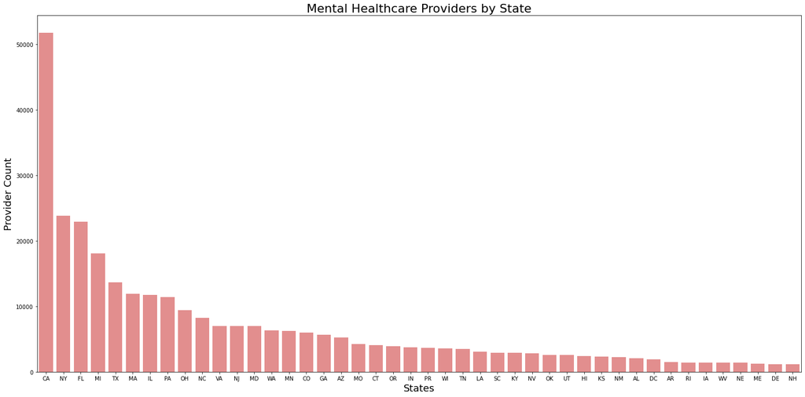

```python
# Plot mental healthcare Providers by State

plt.figure(figsize=(25,12))
sns.barplot(mental_count_df['regionabbr'].iloc[:-19],
            mental_count_df['Provider_Count'].iloc[:-19],
            color='lightcoral')
plt.title('Mental Healthcare Providers by State', fontsize=22)
plt.xlabel('States', fontsize=18)
plt.ylabel('Provider Count', fontsize=18);
```

#### DataFrame for Population by State

We will use the population density layer at state level to create this dataframe

```python
# State population dataframe
state_layer = popdensity.layers[43]
state_df = state_layer.query(out_fields='STATE_NAME,ST_ABBREV,TOTPOP_CY', as_df=True)

state_df.head()
```

|  | OBJECTID | STATE_NAME | ST_ABBREV | TOTPOP_CY | SHAPE |
| --- | --- | --- | --- | --- | --- |
| 0 | 1 | Alabama | AL | 5028316 | {"rings": [[[-9804885.6072097, 3535086.3690447... |
| 1 | 2 | Alaska | AK | 760206 | {"rings": [[[-19937055.7493677, 6661392.287859... |
| 2 | 3 | Arizona | AZ | 7332436 | {"rings": [[[-12138858.697798947, 4438979.1094... |
| 3 | 4 | Arkansas | AR | 3107082 | {"rings": [[[-9989042.442704434, 4300705.03222... |
| 4 | 5 | California | CA | 39648525 | {"rings": [[[-13198542.771785328, 3897777.9747... |

#### Merge Provider Count and Population Dataframes

```python
# Merge provider count and population at state level
# Merge with State data on left to preserve 'polygon' geometry
state_mental_df = pd.merge(state_df,mental_count_df,right_on='regionabbr',
                           left_on='ST_ABBREV',how='inner')
```

```python
state_mental_df.head()
```

|  | OBJECTID | STATE_NAME | ST_ABBREV | TOTPOP_CY | SHAPE | regionabbr | Provider_Count |
| --- | --- | --- | --- | --- | --- | --- | --- |
| 0 | 1 | Alabama | AL | 5028316 | {'rings': [[[-9804885.6072097, 3535086.3690447... | AL | 2030 |
| 1 | 2 | Alaska | AK | 760206 | {'rings': [[[-19937055.7493677, 6661392.287859... | AK | 678 |
| 2 | 3 | Arizona | AZ | 7332436 | {'rings': [[[-12138858.697798947, 4438979.1094... | AZ | 5237 |
| 3 | 4 | Arkansas | AR | 3107082 | {'rings': [[[-9989042.442704434, 4300705.03222... | AR | 1507 |
| 4 | 5 | California | CA | 39648525 | {'rings': [[[-13198542.771785328, 3897777.9747... | CA | 51773 |

```python
# Create new columns that shows people per provider
state_mental_df['people_per_prov'] = state_mental_df['TOTPOP_CY']/state_mental_df['Provider_Count']
```

```python
# Arrange dataframe by people_per_prov descending
state_mental_df = state_mental_df.sort_values(by=['people_per_prov'], ascending=False)
state_mental_df.head()
```

|  | OBJECTID | STATE_NAME | ST_ABBREV | TOTPOP_CY | SHAPE | regionabbr | Provider_Count | people_per_prov |
| --- | --- | --- | --- | --- | --- | --- | --- | --- |
| 24 | 25 | Mississippi | MS | 3056560 | {'rings': [[[-9847927.844922382, 3530344.94964... | MS | 1108 | 2758.63 |
| 0 | 1 | Alabama | AL | 5028316 | {'rings': [[[-9804885.6072097, 3535086.3690447... | AL | 2030 | 2477 |
| 12 | 13 | Idaho | ID | 1856821 | {'rings': [[[-12918525.160544802, 6275004.9437... | ID | 790 | 2350.41 |
| 15 | 16 | Iowa | IA | 3238386 | {'rings': [[[-10154308.583250534, 5388473.6788... | IA | 1396 | 2319.76 |
| 43 | 44 | Texas | TX | 29806340 | {'rings': [[[-10518119.492156893, 3980279.4459... | TX | 13621 | 2188.26 |

```python
# Check geometry type
state_mental_df.spatial.geometry_type
```

```
['polygon']
```

#### Plot Shortage

Let's plot the number of people per mental healthcare provider accross all states on a map.

[figure not shown]

```python
mental_shortage_map = gis.map('USA', zoomlevel=4)
mental_shortage_map
```

```python
mental_shortage_map = gis.map('USA', zoomlevel=4)
mental_shortage_map
```

[figure not shown]

##### Define Renderer

```python
# Define Renderer
esriTest = {"renderer": { #This tells python to use JS autocasting
                 "type": "classBreaks",
                 "field":"people_per_prov",
                 "transparency":.5,
                 "minValue":1}}
```

```python
# Define Manual Class breaks
esriTest['renderer']["classBreakInfos"] = [{
  "classMaxValue": 1000.00,
  "label": "0 - 1000.00",
  "description": "0 - 1000.00",
  "symbol": {
    "type": "esriSFS",
    "style": "esriSFSSolid",
    "color": [255,247,236,178.5],
    "outline": {
      "style": "esriSLSSolid",
      "type": "esriSLS",
      "color": [128,128,128,255],
      "width": 2
    }
  }
}, {
  "classMaxValue": 1500.00,
  "label": "1000.001 - 1500.00",
  "description": "1000.001 - 1500.00",
  "symbol": {
    "type": "esriSFS",
    "style": "esriSFSSolid",
    "color": [253,220,174,178.5],
    "outline": {
      "style": "esriSLSSolid",
      "type": "esriSLS",
      "color": [128,128,128,255],
      "width": 2
    }
  }
}, {
  "classMaxValue": 2000.00,
  "label": "1500.001 - 2000.00",
  "description": "1500.001 - 2000.00",
  "symbol": {
    "type": "esriSFS",
    "style": "esriSFSSolid",
    "color": [252,177,123,178.5],
    "outline": {
      "style": "esriSLSSolid",
      "type": "esriSLS",
      "color": [128,128,128,255],
      "width": 2
    }
  }
}, {
  "classMaxValue": 2500.00,
  "label": "2000.001 - 2500.00",
  "description": "2000.001 - 2500.00",
  "symbol": {
    "type": "esriSFS",
    "style": "esriSFSSolid",
    "color": [241,109,75,178.5],
    "outline": {
      "style": "esriSLSSolid",
      "type": "esriSLS",
      "color": [128,128,128,255],
      "width": 2
    }
  }
}, {
  "classMaxValue": 3000.00,
  "label": "2500.001 - 3000.00",
  "description": "2500.001 - 3000.00",
  "symbol": {
    "type": "esriSFS",
    "style": "esriSFSSolid",
    "color": [200,28,18,178.5],
    "outline": {
      "style": "esriSLSSolid",
      "type": "esriSLS",
      "color": [128,128,128,255],
      "width": 2
    }
  }
}]
```

##### Plot Map

```python
# Plot Map using defined Renderer
state_mental_df.spatial.plot(map_widget=mental_shortage_map, renderer=esriTest['renderer'])
```

```
True
```

```python
# Add Legend
mental_shortage_map.legend=True
```

```python
# Save as a Web Map Item
mental_shortage_item = mental_shortage_map.save({'title':'mental_shortage_map',
                                                'snippet':'shortage map',
                                                'tags':'Mental Health',
                                                'typeKeywords':'WebMap'})
mental_shortage_item
```

[figure not shown]

[**mental_shortage_map**](https://datascienceqa.esri.com/portal/home/item.html?id=d0cbe9d8c63f4a53ae9a382529a97103)  
shortage map

[figure not shown]

Web Map by portaladmin  
Last Modified: August 11, 2020  
0 comments, 0 views

#### Plot Population per Mental Healthcare Provider

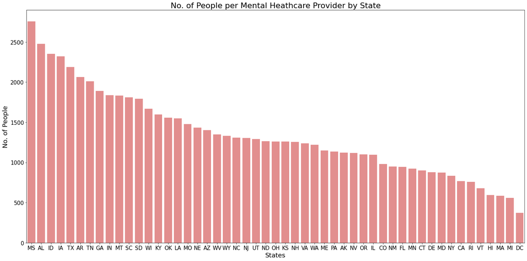

```python
# Plot No. of People per Mental Heathcare Provider by State

plt.figure(figsize=(25,12))
sns.barplot(state_mental_df['regionabbr'], state_mental_df['people_per_prov'], color='lightcoral')
plt.title('No. of People per Mental Heathcare Provider by State', fontsize=22)
plt.xlabel('States', fontsize=18)
plt.ylabel('No. of People', fontsize=18)
plt.xticks(fontsize=15)
plt.yticks(fontsize=15);
```

### Exploring Mississippi

Mississippi has the highest number of people per mental healthcare provider. Let's explore Mississippi to find out which counties have the lowest number of providers.

#### DataFrame for Population in Mississippi

```python
# County population df
county_layer = popdensity.layers[46]
MS_pop_df = county_layer.query(where="ST_ABBREV='MS'",
                               out_fields='ST_ABBREV,NAME,TOTPOP_CY', as_df=True)

MS_pop_df.head()
```

|  | OBJECTID | ST_ABBREV | NAME | TOTPOP_CY | SHAPE |
| --- | --- | --- | --- | --- | --- |
| 0 | 1402 | MS | Adams County | 29894 | {"rings": [[[-10165458.1208, 3730508.161499999... |
| 1 | 1403 | MS | Alcorn County | 37214 | {"rings": [[[-9838473.1467, 4163284.5766000003... |
| 2 | 1404 | MS | Amite County | 12759 | {"rings": [[[-10079714.5057, 3632712.780100003... |
| 3 | 1405 | MS | Attala County | 19625 | {"rings": [[[-9957952.356, 3933319.7764], [-99... |
| 4 | 1406 | MS | Benton County | 8961 | {"rings": [[[-9917285.1197, 4109417.663400002]... |

#### DataFrame for Mental Healthcare Providers in Mississippi by County

```python
# Get provider data for obgyn providers only
mental_MS_df = mental_df[mental_df['regionabbr']=='MS']
mental_MS_df.head()
mental_MS_df.shape
```

```
(1108, 12)
```

```python
# Create dataframe of provider counts by county
mental_MScounty_df = pd.DataFrame(mental_MS_df['subregion'].value_counts().reset_index().values,
                                  columns=['County','Provider_Count'])
mental_MScounty_df.head()
```

|  | County | Provider_Count |
| --- | --- | --- |
| 0 | Hinds County | 274 |
| 1 | Harrison County | 143 |
| 2 | Rankin County | 81 |
| 3 | Lamar County | 76 |
| 4 | Lauderdale County | 52 |

#### Merge Provider Count and Population Dataframes for MS

```python
# Merge provider count and women data at county level for ND
county_mental_df = pd.merge(MS_pop_df,mental_MScounty_df,
                            left_on='NAME', right_on='County',how='left')
```

```python
county_mental_df.head()
```

|  | OBJECTID | ST_ABBREV | NAME | TOTPOP_CY | SHAPE | County | Provider_Count |
| --- | --- | --- | --- | --- | --- | --- | --- |
| 0 | 1402 | MS | Adams County | 29894 | {'rings': [[[-10165458.1208, 3730508.161499999... | Adams County | 7 |
| 1 | 1403 | MS | Alcorn County | 37214 | {'rings': [[[-9838473.1467, 4163284.5766000003... | Alcorn County | 17 |
| 2 | 1404 | MS | Amite County | 12759 | {'rings': [[[-10079714.5057, 3632712.780100003... | Amite County | 1 |
| 3 | 1405 | MS | Attala County | 19625 | {'rings': [[[-9957952.356, 3933319.7764], [-99... | Attala County | 1 |
| 4 | 1406 | MS | Benton County | 8961 | {'rings': [[[-9917285.1197, 4109417.663400002]... | Benton County | 1 |

```python
# Look at null values
county_mental_df[county_mental_df['Provider_Count'].isnull()]
```

|  | OBJECTID | ST_ABBREV | NAME | TOTPOP_CY | SHAPE | County | Provider_Count |
| --- | --- | --- | --- | --- | --- | --- | --- |
| 6 | 1408 | MS | Calhoun County | 14877 | {'rings': [[[-9934761.9179, 4050465.1162], [-9... | NaN | NaN |
| 7 | 1409 | MS | Carroll County | 10936 | {'rings': [[[-9995030.8748, 3985476.520499997]... | NaN | NaN |
| 20 | 1422 | MS | Greene County | 13482 | {'rings': [[[-9844205.9891, 3647601.8276000023... | NaN | NaN |
| 27 | 1429 | MS | Issaquena County | 1363 | {'rings': [[[-10120537.7007, 3896325.656000003... | NaN | NaN |
| 28 | 1430 | MS | Itawamba County | 23874 | {'rings': [[[-9832760.787, 4091219.4390999973]... | NaN | NaN |
| 34 | 1436 | MS | Kemper County | 11229 | {'rings': [[[-9834841.7935, 3885894.5637999997... | NaN | NaN |
| 39 | 1441 | MS | Leake County | 22319 | {'rings': [[[-9942963.7433, 3886235.684799999]... | NaN | NaN |
| 48 | 1450 | MS | Montgomery County | 10553 | {'rings': [[[-9963859.4135, 3985593.969899997]... | NaN | NaN |
| 51 | 1453 | MS | Noxubee County | 11462 | {'rings': [[[-9830004.6277, 3933636.4505999982... | NaN | NaN |
| 62 | 1464 | MS | Sharkey County | 4806 | {'rings': [[[-10096883.1994, 3908092.367399998... | NaN | NaN |
| 67 | 1469 | MS | Tallahatchie County | 14241 | {'rings': [[[-10011126.2815, 4050885.2654], [-... | NaN | NaN |
| 70 | 1472 | MS | Tishomingo County | 19823 | {'rings': [[[-9818385.2662, 4163288.041699998]... | NaN | NaN |
| 71 | 1473 | MS | Tunica County | 11035 | {'rings': [[[-10064171.5218, 4141205.537699997... | NaN | NaN |
| 73 | 1475 | MS | Walthall County | 15166 | {'rings': [[[-10023258.8259, 3676464.274899997... | NaN | NaN |
| 76 | 1478 | MS | Wayne County | 20559 | {'rings': [[[-9847815.2452, 3723726.261], [-98... | NaN | NaN |
| 77 | 1479 | MS | Webster County | 10099 | {'rings': [[[-9909506.6702, 3970155.0966000035... | NaN | NaN |
| 78 | 1480 | MS | Wilkinson County | 9583 | {'rings': [[[-10147678.8396, 3677856.414300002... | NaN | NaN |
| 80 | 1482 | MS | Yalobusha County | 12806 | {'rings': [[[-9964179.5684, 4050586.4976999983... | NaN | NaN |

> We can see that,
> - 18 counties in Mississippi do not have any mental healthcare provider.

We will replace NaN values for Provider Count in these counties with 1 to plot them on the map to see which counties have highest number of people per provider.

```python
county_mental_df['Provider_Count'].replace(np.nan,1,inplace=True)
```

```python
# Create new columns that shows Mental Healthcare provider by population
county_mental_df['people_per_prov'] = county_mental_df['TOTPOP_CY']/county_mental_df['Provider_Count']
```

#### Plot Shortage

Let's plot the number of people per provider for all counties in Mississippi on a map.

[figure not shown]

```python
mental_countyshortage_map = gis.map('Mississippi, USA', zoomlevel=7)
mental_countyshortage_map.layout.height="650px"
mental_countyshortage_map
```

##### Define Renderer

```python
# Define Renderer
mentalCountyTest = {"renderer": { #This tells python to use JS autocasting
                 "type": "classBreaks",
                 "field":"people_per_prov",
                 "transparency":.5,
                 "minValue":1}}
```

```python
# Define Manual Class breaks
mentalCountyTest['renderer']["classBreakInfos"] = [{
  "classMaxValue": 7500.00,
  "label": "0 - 7500.00",
  "description": "0 - 7500.00",
  "symbol": {
    "type": "esriSFS",
    "style": "esriSFSSolid",
    "color": [255,247,236,178.5],
    "outline": {
      "style": "esriSLSSolid",
      "type": "esriSLS",
      "color": [128,128,128,255],
      "width": 2
    }
  }
}, {
  "classMaxValue": 15000.00,
  "label": "7500.001 - 15000.00",
  "description": "7500.001 - 15000.00",
  "symbol": {
    "type": "esriSFS",
    "style": "esriSFSSolid",
    "color": [253,220,174,178.5],
    "outline": {
      "style": "esriSLSSolid",
      "type": "esriSLS",
      "color": [128,128,128,255],
      "width": 2
    }
  }
}, {
  "classMaxValue": 22500.00,
  "label": "15000.001 - 22500.00",
  "description": "15000.001 - 22500.00",
  "symbol": {
    "type": "esriSFS",
    "style": "esriSFSSolid",
    "color": [252,177,123,178.5],
    "outline": {
      "style": "esriSLSSolid",
      "type": "esriSLS",
      "color": [128,128,128,255],
      "width": 2
    }
  }
}, {
  "classMaxValue": 30000.00,
  "label": "22500.001 - 30000.00",
  "description": "22500.001 - 30000.00",
  "symbol": {
    "type": "esriSFS",
    "style": "esriSFSSolid",
    "color": [241,109,75,178.5],
    "outline": {
      "style": "esriSLSSolid",
      "type": "esriSLS",
      "color": [128,128,128,255],
      "width": 2
    }
  }
}, {
  "classMaxValue": 37500.00,
  "label": "30000.001 - 37500.00",
  "description": "30000.001 - 37500.00",
  "symbol": {
    "type": "esriSFS",
    "style": "esriSFSSolid",
    "color": [200,28,18,178.5],
    "outline": {
      "style": "esriSLSSolid",
      "type": "esriSLS",
      "color": [128,128,128,255],
      "width": 2
    }
  }
}]
```

##### Plot Map

```python
# Plot Map using defined Renderer
county_mental_df.spatial.plot(map_widget=mental_countyshortage_map, renderer=mentalCountyTest['renderer'])
```

```
True
```

```python
# Plot legend
mental_countyshortage_map.legend = True
```

```python
# Save as a Web Map Item
mental_cs_item = mental_countyshortage_map.save({'title':'mental_countyshortage_map',
                                                'snippet':'shortage map',
                                                'tags':'Mental Health',
                                                'typeKeywords':'WebMap'})
mental_cs_item
```

[figure not shown]

[**mental_countyshortage_map**](https://datascienceqa.esri.com/portal/home/item.html?id=c69efc46269040e69428cb60a10d6260)  
shortage map

[figure not shown]

Web Map by portaladmin  
Last Modified: August 11, 2020  
0 comments, 0 views

The table below shows top 10 counties with highest number of people per mental healthcare provider

```python
# Counties with highest number of people per mental healthcare provider
county_ppp = county_mental_df.sort_values(by='people_per_prov', ascending=False)[['NAME','TOTPOP_CY','Provider_Count','people_per_prov']]
county_ppp.head(10)
```

|  | NAME | TOTPOP_CY | Provider_Count | people_per_prov |
| --- | --- | --- | --- | --- |
| 46 | Marshall County | 36641 | 1 | 36641.0 |
| 57 | Pontotoc County | 32568 | 1 | 32568.0 |
| 49 | Neshoba County | 29284 | 1 | 29284.0 |
| 72 | Union County | 28332 | 1 | 28332.0 |
| 61 | Scott County | 28263 | 1 | 28263.0 |
| 28 | Itawamba County | 23874 | 1 | 23874.0 |
| 39 | Leake County | 22319 | 1 | 22319.0 |
| 76 | Wayne County | 20559 | 1 | 20559.0 |
| 70 | Tishomingo County | 19823 | 1 | 19823.0 |
| 3 | Attala County | 19625 | 1 | 19625.0 |

###### Marshall County Infographic

To visualize high level key facts about a geography and gain greater insights, various infographics can be created using ArcGIS Business Analyst. Learn more about [ArcGIS Business Analyst](https://www.esri.com/en-us/arcgis/products/arcgis-business-analyst/overview).

The image below shows an infographic of key facts for `Marshall County, MS`.

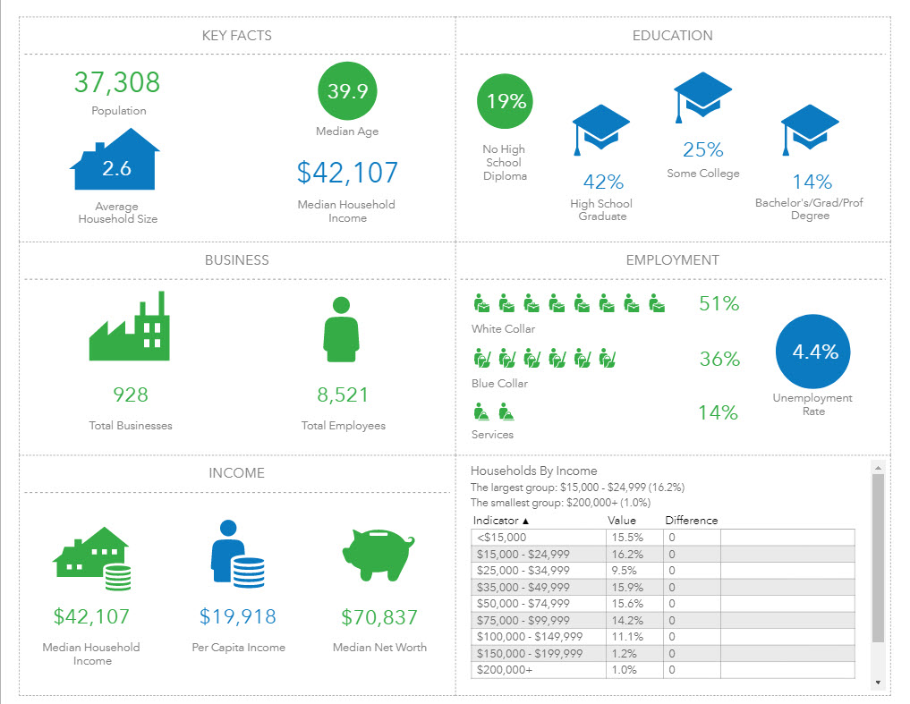

## Women's Health

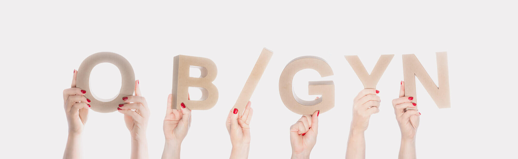

Image source: https://www.aamc.org/news-insights/labor-pains-ob-gyn-shortage

- Half of U.S. counties lack a single OB-GYN and women’s lives are endangered by long treks for much-needed care [[4]](https://news.aamc.org/patient-care/article/labor-pains-obgyn-shortage/).
- With a severe shortage of obstetrician/gynecologists forecasted, some metropolitan areas are prone to crisis-level conditions [[5]](https://www.medpagetoday.com/obgyn/generalobgyn/73785).
- By 2020, there will be a shortage of up to 8,800 OB-GYNs, and the shortage may grow upto 22,000 by 2050 [[6]](http://fortune.com/2018/06/27/these-cities-are-most-likely-to-face-an-ob-gyn-shortage-by-2020/).

The table below shows a list of providers shortlisted as OB-GYN providers. Provider Taxonomy codes were filtered for OB-GYN providers using this [reference](http://www.wpc-edi.com/reference/codelists/healthcare/health-care-provider-taxonomy-code-set/).

| Taxonomy Code | Description |
| --- | --- |
| 207V00000X | Obstetrics & Gynecology |
| 207VC0200X | Critical Care Medicine |
| 207VF0040X | Female Pelvic Medicine and Reconstructive Surgery |
| 207VX0201X | Gynecologic Oncology |
| 207VG0400X | Gynecology |
| 207VH0002X | Hospice and Palliative Medicine |
| 207VM0101X | Maternal & Fetal Medicine |
| 207VB0002X | Obesity Medicine |
| 207VX0000X | Obstetrics |
| 207VE0102X | Reproductive Endocrinology |
| 363LX0001X | Nurse Practitioner-Obstetrics & Gynecology |
| 163WR1000X | Registered Nurse-Reproductive Endocrinology/Infertility |
| 163WW0101X | Registered Nurse-Women's Health Care, Ambulatory |
| 282NW0100X | General Acute Care Hospital - Women |

### OBGYN Providers - Heat Map

Let's explore the distribution of OB-GYN providers in US using a heatmap.

[figure not shown]

```python
# Create Map
women_map = gis.map('USA', 4)
women_map
```

This map paints a grim picture of the availability of OBGYN healthcare providers. We can see vast areas in Midwest and West with NO or very few OBGYN providers.

```python
# Define renderer and add provider data for OBGYN providers
renderer = {"renderer": "autocast", #This tells python to use JS autocasting
            "type": "heatmap",
            "blurRadius":1,  # changes the size of the clusters
            "maxPixelIntensity":2,
            "minPixelIntensity":0,
            "field":None}
renderer["colorStops"] = [{"ratio":0,"color":[63, 40, 102, 0]},
                          {"ratio":0.25,"color":[167,97,170,179]},
                          {"ratio":0.50,"color":"#7b3ce9"},
                          {"ratio":0.75,"color":[222,102,0,179]},
                          {"ratio":1,"color":[244,204,0,179]}]
women_map.add_layer(provider_data_layer,
               { "type": "FeatureLayer",
                 "renderer": renderer,
                "definition_expression" : "user_taxonomy_code_1 in ('207V00000X','207VC0200X','207VF0040X','207VX0201X','207VG0400X','207VH0002X','207VM0101X','207VB0002X','207VX0000X','207VE0102X','363LX0001X','163WR1000X','163WW0101X','282NW0100X')"
#                 "definition_expression" : "user_taxonomy_code_1 = '207VC0200X' or user_taxonomy_code_1 = '207V00000X'"
                })
```

```python
# Add Legend
women_map.legend = True
```

```python
# Save as a web map item
women_map_item = women_map.save({'title':'women_heatmap',
                                    'snippet':'Heat map',
                                    'tags':'Women Health',
                                    'typeKeywords':'WebMap'})
women_map_item
```

[figure not shown]

[**women_heatmap**](https://datascienceqa.esri.com/portal/home/item.html?id=0a263209db724c8daf7b4b0e037df198)  
Heat map

[figure not shown]

Web Map by portaladmin  
Last Modified: August 11, 2020  
0 comments, 0 views

### Mothers to Providers Ratio by State

In this section our goal is to identify which states have the highest mother's to providers ratio. Let's get data from the American Community Survey (ACS) about fertility in past 12 months by age of mother using ACS_Fertility_by_Age_Boundaries layer at State, County and Tract level. We will merge OBGYN providers data with Fertility data to achieve this.

#### Get the layers

[figure not shown]

[**ACS Fertility in Past 12 Months by Age Variables - Boundaries**](https://datascienceqa.esri.com/portal/home/item.html?id=7995cd11748249fb8e23c4a5ad901dde)  
This layer contains the most current release of data from the American Community Survey (ACS) about fertility in past 12 months by age of mother. These are 5-year estimates shown by tract, county, and state boundaries.

[figure not shown]

Feature Layer Collection by esri_livingatlas  
Last Modified: May 13, 2020  
0 comments, 0 views

```python
fertility_item = gis.content.get('7995cd11748249fb8e23c4a5ad901dde')
fertility_item
```

```python
fertility_item.layers
```

```
[<FeatureLayer url:"https://services.arcgis.com/P3ePLMYs2RVChkJx/arcgis/rest/services/ACS_Fertility_by_Age_Boundaries/FeatureServer/0">,
 <FeatureLayer url:"https://services.arcgis.com/P3ePLMYs2RVChkJx/arcgis/rest/services/ACS_Fertility_by_Age_Boundaries/FeatureServer/1">,
 <FeatureLayer url:"https://services.arcgis.com/P3ePLMYs2RVChkJx/arcgis/rest/services/ACS_Fertility_by_Age_Boundaries/FeatureServer/2">]
```

```python
# Define layers for State, County and Tract (Percent of women 15 to 50 who had a birth in the past 12 months)
fertility_state = fertility_item.layers[0]
fertility_county = fertility_item.layers[1]
fertility_tract = fertility_item.layers[2]
```

#### DataFrame for women population by State

We will use the fertility layer at state level to create this dataframe

```python
# State population dataframe
fertility_df = fertility_state.query(where="B13016_001E>1", as_df=True)
fertility_df.head()
```

|  | OBJECTID | STATENS | GEOID | STUSPS | NAME | ALAND | AWATER | B13016_001E | B13016_001M | B13016_002E | B13016_002M | B13016_003E | B13016_003M | B13016_004E | B13016_004M | B13016_005E | B13016_005M | B13016_006E | B13016_006M | B13016_007E | B13016_007M | B13016_008E | B13016_008M | B13016_009E | B13016_009M | B13016_010E | B13016_010M | B13016_011E | B13016_011M | … |
| --- | --- | --- | --- | --- | --- | --- | --- | --- | --- | --- | --- | --- | --- | --- | --- | --- | --- | --- | --- | --- | --- | --- | --- | --- | --- | --- | --- | --- | --- | --- |
| 0 | 1 | 01779775 | 01 | AL | Alabama | 131174048583 | 4593327154 | 1148528 | 1509 | 60165 | 1702 | 2589 | 441 | 14746 | 793 | 19098 | 1127 | 14125 | 810 | 6813 | 626 | 1958 | 470 | 836 | 220 | 1088363 | 2107 | 157525 | 1206 | … |
| 1 | 2 | 01785533 | 02 | AK | Alaska | 1478839695958 | 245481577452 | 173058 | 528 | 10777 | 673 | 505 | 165 | 2225 | 253 | 3105 | 378 | 2921 | 345 | 1512 | 295 | 396 | 124 | 113 | 58 | 162281 | 896 | 21785 | 316 | … |
| 2 | 3 | 01779777 | 04 | AZ | Arizona | 294198551143 | 1027337603 | 1598426 | 1260 | 87762 | 2110 | 3435 | 460 | 17844 | 1040 | 24962 | 1126 | 22224 | 1223 | 13423 | 836 | 3793 | 412 | 2081 | 349 | 1510664 | 2549 | 225915 | 906 | … |
| 3 | 4 | 00068085 | 05 | AR | Arkansas | 134768872727 | 2962859592 | 690046 | 1218 | 40212 | 1649 | 2509 | 364 | 10514 | 749 | 12755 | 850 | 8907 | 646 | 4078 | 511 | 1032 | 229 | 417 | 124 | 649834 | 2039 | 95475 | 960 | … |
| 4 | 5 | 01779778 | 06 | CA | California | 403503931312 | 20463871877 | 9632116 | 4019 | 473280 | 5293 | 13945 | 824 | 70111 | 2050 | 118935 | 2794 | 139069 | 2870 | 90663 | 1976 | 29631 | 1189 | 10926 | 665 | 9158836 | 6208 | 1249040 | 1197 | … |

#### DataFrame for OB-GYN providers by state

We will use `provider_data_layer` to subset OB-GYN providers

```python
%%time

# Get provider data for obgyn providers only
taxonomy_codes = ['207V00000X','207VC0200X','207VF0040X','207VX0201X','207VG0400X',
                  '207VH0002X','207VM0101X','207VB0002X','207VX0000X','207VE0102X',
                  '363LX0001X','163WR1000X','163WW0101X','282NW0100X']

out_fields = ['user_npi','user_entity_type','user_provider_gender','user_taxonomy_code_1',
              'user_full_address','postal','city','subregion','region','regionabbr']

where_str = "user_taxonomy_code_1 in ({})".format(",".join(f"'{x}'" for x in taxonomy_codes))
out_str = "{}".format(",".join(f"{x}" for x in out_fields))

obgyn_df = provider_data_layer.query(where=where_str,
                                     out_fields=out_str, as_df=True)

obgyn_df.head()
```

```
Wall time: 1min 56s
```

|  | SHAPE | city | objectid | postal | region | regionabbr | subregion | user_entity_type | user_full_address | user_npi | user_provider_gender | user_taxonomy_code_1 |
| --- | --- | --- | --- | --- | --- | --- | --- | --- | --- | --- | --- | --- |
| 0 | {"x": -8198939.4947, "y": 5358600.421800002, "... | Glens Falls | 260 | 12801 | New York | NY | Warren County | Individual | 45 HUDSON AVE, , GLENS FALLS, NY 128014313 | 1.659501e+09 | F | 207V00000X |
| 1 | {"x": -8223678.4574, "y": 5061654.650899999, "... | Putnam Valley | 393 | 10579 | New York | NY | Putnam County | Organization | 11 PEEKSKILL HOLLOW RD # 204, , PUTNAM VALLEY,... | 1.013428e+09 | None | 207VX0201X |
| 2 | {"x": -8232526.3719999995, "y": 4962867.355700... | Brooklyn | 455 | 11225 | New York | NY | Kings County | Individual | 249 EMPIRE BLVD, , BROOKLYN, NY 112253402 | 1.841430e+09 | M | 207V00000X |
| 3 | {"x": -8603908.3159, "y": 5292933.3891, "spati... | Canandaigua | 574 | 14424 | New York | NY | Ontario County | Individual | 335 PARRISH ST, , CANANDAIGUA, NY 144241728 | 1.235132e+09 | M | 207V00000X |
| 4 | {"x": -8193198.8078000005, "y": 4973209.799699... | Garden City | 734 | 11530 | New York | NY | Nassau County | Organization | 901 STEWART AVE, , GARDEN CITY, NY 115304893 | 1.346479e+09 | None | 207VM0101X |

```python
# Create dataframe of obgyn provider counts by state
obgyn_count_df = pd.DataFrame(obgyn_df['regionabbr'].value_counts().reset_index().values,
                              columns=['regionabbr','Provider_Count'])
```

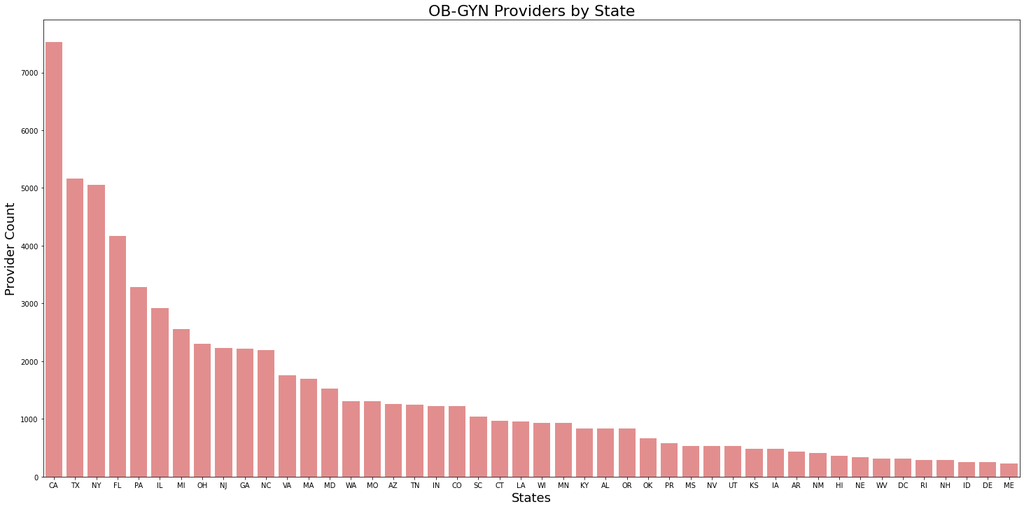

```python
# Plot OB-GYN Providers by State

plt.figure(figsize=(25,12))
sns.barplot(obgyn_count_df['regionabbr'].iloc[:-8],
            obgyn_count_df['Provider_Count'].iloc[:-8],
            color='lightcoral')
plt.title('OB-GYN Providers by State', fontsize=22)
plt.xlabel('States', fontsize=18)
plt.ylabel('Provider Count', fontsize=18);
```

#### Merge Provider Count and Population Dataframes

```python
# Merge provider count and women_df at state level
state_obgyn_df = pd.merge(fertility_df,obgyn_count_df,right_on='regionabbr',
                          left_on='STUSPS',how='inner')
```

Create 2 new attributes: `women_per_prov` and `mother_per_prov` to capture the number of women and mothers per OB-GYN provider

```python
# Create new columns that shows provider by women pop
state_obgyn_df['women_per_prov'] = state_obgyn_df['B13016_001E']/state_obgyn_df['Provider_Count']

# Create new columns that shows provider by mother pop
state_obgyn_df['mother_per_prov'] = state_obgyn_df['B13016_002E']/state_obgyn_df['Provider_Count']
```

```python
# Arrange dataframe by mother_per_prov descending
state_obgyn_df = state_obgyn_df.sort_values(by=['mother_per_prov'], ascending=False)
```

```python
# Subset dataframe for specific columns
state_obgyn_df = state_obgyn_df.loc[:,['OBJECTID','SHAPE','regionabbr','Provider_Count',
                                       'women_per_prov','mother_per_prov']]
state_obgyn_df.head()
```

|  | OBJECTID | SHAPE | regionabbr | Provider_Count | women_per_prov | mother_per_prov |
| --- | --- | --- | --- | --- | --- | --- |
| 34 | 35 | {'rings': [[[-10823452.8858, 6274958.149], [-1... | ND | 102 | 1661.49 | 111.353 |
| 44 | 45 | {'rings': [[[-12139394.6091, 5012444.5138], [-... | UT | 526 | 1441.92 | 99.9943 |
| 12 | 13 | {'rings': [[[-12918526.7316, 6275006.0277], [-... | ID | 250 | 1535.15 | 93.66 |
| 3 | 4 | {'rings': [[[-9989043.0946, 4300705.9503], [-9... | AR | 440 | 1568.29 | 91.3909 |
| 41 | 42 | {'rings': [[[-10749419.778, 5769979.5139], [-1... | SD | 137 | 1368.78 | 91.0584 |

```python
# Check geometry type
state_obgyn_df.spatial.geometry_type
```

```
['polygon']
```

#### Plot Shortage

Let's plot the number of Mothers per OBGYN provider accross all states on a map.

[figure not shown]

```python
obgyn_shortage_map = gis.map('USA', zoomlevel=4)
obgyn_shortage_map
```

> From this map, we can see that number of women (ages 15 to 50) who had a birth in the past 12 months per OBGYN provider is high in Utah, North Dakota, South Dakota and Arkansas.

[output not shown]

##### Define Renderer

```python
# Define Renderer
stateObgynTest = {"renderer": { #This tells python to use JS autocasting
                 "type": "classBreaks",
                 "field":"mother_per_prov",
                 "transparency":.5,
                 "minValue":1}}
```

```python
# Define Manual Class breaks
stateObgynTest['renderer']["classBreakInfos"] = [{
  "classMaxValue": 23.00,
  "label": "0 - 23.00",
  "description": "0 - 23.00",
  "symbol": {
    "type": "esriSFS",
    "style": "esriSFSSolid",
    "color": [255,247,236,178.5],
    "outline": {
      "style": "esriSLSSolid",
      "type": "esriSLS",
      "color": [128,128,128,255],
      "width": 2
    }
  }
}, {
  "classMaxValue": 46.00,
  "label": "23.001 - 46.00",
  "description": "23.001 - 46.00",
  "symbol": {
    "type": "esriSFS",
    "style": "esriSFSSolid",
    "color": [253,220,174,178.5],
    "outline": {
      "style": "esriSLSSolid",
      "type": "esriSLS",
      "color": [128,128,128,255],
      "width": 2
    }
  }
}, {
  "classMaxValue": 69.00,
  "label": "46.001 - 69.00",
  "description": "46.001 - 69.00",
  "symbol": {
    "type": "esriSFS",
    "style": "esriSFSSolid",
    "color": [252,177,123,178.5],
    "outline": {
      "style": "esriSLSSolid",
      "type": "esriSLS",
      "color": [128,128,128,255],
      "width": 2
    }
  }
}, {
  "classMaxValue": 92.00,
  "label": "69.001 - 92.00",
  "description": "69.001 - 92.00",
  "symbol": {
    "type": "esriSFS",
    "style": "esriSFSSolid",
    "color": [241,109,75,178.5],
    "outline": {
      "style": "esriSLSSolid",
      "type": "esriSLS",
      "color": [128,128,128,255],
      "width": 2
    }
  }
}, {
  "classMaxValue": 115.00,
  "label": "92.001 - 115.00",
  "description": "92.001 - 115.00",
  "symbol": {
    "type": "esriSFS",
    "style": "esriSFSSolid",
    "color": [200,28,18,178.5],
    "outline": {
      "style": "esriSLSSolid",
      "type": "esriSLS",
      "color": [128,128,128,255],
      "width": 2
    }
  }
}]
```

##### Plot Map

```python
# Plot Map using defined Renderer
state_obgyn_df.spatial.plot(map_widget=obgyn_shortage_map, renderer=stateObgynTest['renderer'])
```

```
True
```

```python
# Add Legend
obgyn_shortage_map.legend=True
```

#### Plot Mothers per OBGYN Provider

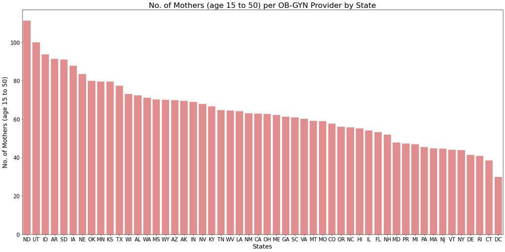

```python
# Plot No. of Mothers (age 15 to 50) per OB-GYN Provider by State

plt.figure(figsize=(25,12))
sns.barplot(state_obgyn_df['regionabbr'], state_obgyn_df['mother_per_prov'],color='lightcoral')
plt.title('No. of Mothers (age 15 to 50) per OB-GYN Provider by State', fontsize=22)
plt.xlabel('States', fontsize=18)
plt.ylabel('No. of Mothers (age 15 to 50)', fontsize=18)
plt.xticks(fontsize=15)
plt.yticks(fontsize=15);
```

### Exploring North Dakota

Let's explore North Dakota to find out which counties have the lowest number of OBGYN providers.

#### DataFrame for women population in North Dakota

```python
# State population df
ND_fertility_df = fertility_county.query(where="STATE='North Dakota'", as_df=True)
ND_fertility_df.head()
```

|  | OBJECTID | COUNTYNS | GEOID | ALAND | AWATER | NAME | State | B13016_001E | B13016_001M | B13016_002E | B13016_002M | B13016_003E | B13016_003M | B13016_004E | B13016_004M | B13016_005E | B13016_005M | B13016_006E | B13016_006M | B13016_007E | B13016_007M | B13016_008E | B13016_008M | B13016_009E | B13016_009M | B13016_010E | B13016_010M | B13016_011E | B13016_011M | … |
| --- | --- | --- | --- | --- | --- | --- | --- | --- | --- | --- | --- | --- | --- | --- | --- | --- | --- | --- | --- | --- | --- | --- | --- | --- | --- | --- | --- | --- | --- | --- |
| 0 | 1991 | 01034210 | 38001 | 2557900104 | 2894336 | Adams County | North Dakota | 425 | 50 | 7 | 10 | 0 | 9 | 0 | 9 | 0 | 9 | 0 | 9 | 7 | 10 | 0 | 9 | 0 | 9 | 418 | 55 | 49 | 25 | … |
| 1 | 1992 | 01034225 | 38003 | 3863107416 | 56591280 | Barnes County | North Dakota | 2185 | 110 | 145 | 63 | 0 | 15 | 0 | 15 | 112 | 52 | 11 | 12 | 22 | 32 | 0 | 15 | 0 | 15 | 2040 | 124 | 365 | 63 | … |
| 2 | 1993 | 01034216 | 38005 | 3596569006 | 131708143 | Benson County | North Dakota | 1359 | 11 | 118 | 37 | 12 | 13 | 51 | 22 | 23 | 13 | 18 | 11 | 7 | 7 | 7 | 7 | 0 | 13 | 1241 | 39 | 227 | 18 | … |
| 3 | 1994 | 01035616 | 38007 | 2975481849 | 11990485 | Billings County | North Dakota | 159 | 31 | 3 | 4 | 0 | 9 | 0 | 9 | 1 | 3 | 0 | 9 | 2 | 3 | 0 | 9 | 0 | 9 | 156 | 31 | 16 | 16 | … |
| 4 | 1995 | 01034227 | 38009 | 4321196488 | 74864998 | Bottineau County | North Dakota | 1182 | 44 | 81 | 46 | 0 | 13 | 11 | 11 | 10 | 10 | 18 | 25 | 42 | 35 | 0 | 13 | 0 | 13 | 1101 | 62 | 167 | 38 | … |

#### DataFrame for OB-GYN providers in North Dakota by County

```python
obgyn_ND_df = obgyn_df[obgyn_df['regionabbr']=='ND']
obgyn_ND_df.head()
```

|  | SHAPE | city | objectid | postal | region | regionabbr | subregion | user_entity_type | user_full_address | user_npi | user_provider_gender | user_taxonomy_code_1 |
| --- | --- | --- | --- | --- | --- | --- | --- | --- | --- | --- | --- | --- |
| 58458 | {"x": -10774354.7173, "y": 5923277.750399999, ... | Fargo | 4972067 | 58102 | North Dakota | ND | Cass County | Individual | 801 BROADWAY N, , FARGO, ND 58122 | 1.851398e+09 | M | 207VM0101X |
| 58459 | {"x": -10805394.5552, "y": 6092239.3112, "spat... | Grand Forks | 4972187 | 58201 | North Dakota | ND | Grand Forks County | Individual | 1000 SOUTH COLUMBIA ROAD, , GRAND FORKS, ND 58... | 1.366440e+09 | M | 207V00000X |
| 58460 | {"x": -11104110.0435, "y": 6247432.4749, "spat... | Belcourt | 4972639 | 58316 | North Dakota | ND | Rolette County | Individual | 1 HOSPITAL ROAD NORTH, , BELCOURT, ND 58316 | 1.164496e+09 | M | 207V00000X |
| 58461 | {"x": -11218390.8501, "y": 5910867.419699997, ... | Bismarck | 4972840 | 58501 | North Dakota | ND | Burleigh County | Individual | 1000 E ROSSER AVE, , BISMARCK, ND 585014414 | 1.982658e+09 | M | 207V00000X |
| 58462 | {"x": -11218390.8501, "y": 5910867.419699997, ... | Bismarck | 4972850 | 58501 | North Dakota | ND | Burleigh County | Individual | 1000 E ROSSER AVE, , BISMARCK, ND 585014414 | 1.093769e+09 | M | 207V00000X |

```python
obgyn_ND_df.shape
```

```
(102, 12)
```

```python
# Create dataframe of obgyn provider counts by county
obgyn_NDcounty_df = pd.DataFrame(obgyn_ND_df['subregion'].value_counts().reset_index().values, columns=['County','Provider_Count'])
obgyn_NDcounty_df.head()
```

|  | County | Provider_Count |
| --- | --- | --- |
| 0 | Cass County | 37 |
| 1 | Burleigh County | 22 |
| 2 | Grand Forks County | 13 |
| 3 | Ward County | 10 |
| 4 | Williams County | 8 |

#### Merge Provider Count and Population DataFrames

```python
# Merge provider count and women data at county level for ND
county_obgyn_df = pd.merge(ND_fertility_df,obgyn_NDcounty_df,left_on='NAME', right_on='County',how='left')
```

```python
# Look at null values
county_obgyn_df[county_obgyn_df['Provider_Count'].isnull()][['NAME','Provider_Count']]
```

|  | NAME | Provider_Count |
| --- | --- | --- |
| 0 | Adams County | NaN |
| 1 | Barnes County | NaN |
| 2 | Benson County | NaN |
| 3 | Billings County | NaN |
| 4 | Bottineau County | NaN |
| 5 | Bowman County | NaN |
| 6 | Burke County | NaN |
| 9 | Cavalier County | NaN |
| 10 | Dickey County | NaN |
| 11 | Divide County | NaN |
| 12 | Dunn County | NaN |
| 13 | Eddy County | NaN |
| 14 | Emmons County | NaN |
| 15 | Foster County | NaN |
| 16 | Golden Valley County | NaN |
| 18 | Grant County | NaN |
| 19 | Griggs County | NaN |
| 20 | Hettinger County | NaN |
| 21 | Kidder County | NaN |
| 22 | LaMoure County | NaN |
| 23 | Logan County | NaN |
| 24 | McHenry County | NaN |
| 25 | McIntosh County | NaN |
| 26 | McKenzie County | NaN |
| 27 | McLean County | NaN |
| 28 | Mercer County | NaN |
| 29 | Morton County | NaN |
| 30 | Mountrail County | NaN |
| 31 | Nelson County | NaN |
| 32 | Oliver County | NaN |
| 33 | Pembina County | NaN |
| 34 | Pierce County | NaN |
| 35 | Ramsey County | NaN |
| 36 | Ransom County | NaN |
| 37 | Renville County | NaN |
| 40 | Sargent County | NaN |
| 41 | Sheridan County | NaN |
| 43 | Slope County | NaN |
| 45 | Steele County | NaN |
| 47 | Towner County | NaN |
| 48 | Traill County | NaN |
| 49 | Walsh County | NaN |
| 51 | Wells County | NaN |

```python
county_obgyn_df[county_obgyn_df['Provider_Count'].isnull()].shape
```

```
(43, 76)
```

> We can see that:
> - 43 out of 53 counties in ND do not have any Obgyn healthcare providers.

We will replace NaN values for Provider Count in these counties with 1 to plot them on the map to see which counties have highest number of mothers per provider.

```python
# Replace NaN with 1
county_obgyn_df['Provider_Count'].replace(np.nan,1,inplace=True)
```

```python
# Create new columns that shows provider by women pop
county_obgyn_df['women_per_prov'] = county_obgyn_df['B13016_001E']/county_obgyn_df['Provider_Count']

# Create new columns that shows provider by mother pop
county_obgyn_df['mother_per_prov'] = county_obgyn_df['B13016_002E']/county_obgyn_df['Provider_Count']
```

```python
# Arrange dataframe by mother_per_prov descending and then B13016_002E (women who gave birht) descending
county_obgyn_df = county_obgyn_df.sort_values(by=['mother_per_prov','B13016_002E'],
                                              ascending=False)[['OBJECTID','SHAPE','NAME','Provider_Count',
                                                                'B13016_001E','B13016_002E','women_per_prov',
                                                                'mother_per_prov']]
county_obgyn_df.columns = ['OBJECTID','SHAPE','Name','Provider_Count', "Total Women (15 to 50)",
                           "Women who had birth (past 12 months)", 'women_per_prov', 'mother_per_prov']
county_obgyn_df.head()
```

|  | OBJECTID | SHAPE | Name | Provider_Count | Total Women (15 to 50) | Women who had birth (past 12 months) | women_per_prov | mother_per_prov |
| --- | --- | --- | --- | --- | --- | --- | --- | --- |
| 29 | 2020 | {'rings': [[[-11236143.3632, 5939274.8243], [-... | Morton County | 1 | 6598 | 555 | 6598.0 | 555.0 |
| 38 | 2029 | {'rings': [[[-10773989.0107, 5881971.3849], [-... | Richland County | 1 | 3342 | 228 | 3342.0 | 228.0 |
| 46 | 2037 | {'rings': [[[-11050272.8328, 5995646.2405], [-... | Stutsman County | 2 | 4237 | 315 | 2118.5 | 157.5 |
| 10 | 2001 | {'rings': [[[-10913159.7795, 5825785.1309], [-... | Dickey County | 1 | 1011 | 151 | 1011.0 | 151.0 |
| 1 | 1992 | {'rings': [[[-10904992.8409, 5981421.7966], [-... | Barnes County | 1 | 2185 | 145 | 2185.0 | 145.0 |

#### Plot Shortage

Let's plot the number of Mothers per OBGYN provider for all counties in North Dakota on a map.

[figure not shown]

```python
obgyn_countyshortage_map = gis.map('North Dakota, USA', zoomlevel=6)
obgyn_countyshortage_map
```

> We can see that:
> - Morton County seems to be the worst with 555 women who gave birth but no provider.

##### Define Renderer

```python
# Define Renderer
obgynCountyTest = {"renderer": { #This tells python to use JS autocasting
                 "type": "classBreaks",
                 "field":"mother_per_prov",
                 "transparency":.5,
                 "minValue":1}}
```

```python
# Define Manual Class breaks
obgynCountyTest['renderer']["classBreakInfos"] = [{
  "classMaxValue": 100.00,
  "label": "0 - 100.00",
  "description": "0 - 100.00",
  "symbol": {
    "type": "esriSFS",
    "style": "esriSFSSolid",
    "color": [255,247,236,178.5],
    "outline": {
      "style": "esriSLSSolid",
      "type": "esriSLS",
      "color": [128,128,128,255],
      "width": 2
    }
  }
}, {
  "classMaxValue": 200.00,
  "label": "100.001 - 200.00",
  "description": "100.001 - 200.00",
  "symbol": {
    "type": "esriSFS",
    "style": "esriSFSSolid",
    "color": [253,220,174,178.5],
    "outline": {
      "style": "esriSLSSolid",
      "type": "esriSLS",
      "color": [128,128,128,255],
      "width": 2
    }
  }
}, {
  "classMaxValue": 300.00,
  "label": "200.001 - 300.00",
  "description": "200.001 - 300.00",
  "symbol": {
    "type": "esriSFS",
    "style": "esriSFSSolid",
    "color": [252,177,123,178.5],
    "outline": {
      "style": "esriSLSSolid",
      "type": "esriSLS",
      "color": [128,128,128,255],
      "width": 2
    }
  }
}, {
  "classMaxValue": 400.00,
  "label": "300.001 - 400.00",
  "description": "300.001 - 400.00",
  "symbol": {
    "type": "esriSFS",
    "style": "esriSFSSolid",
    "color": [241,109,75,178.5],
    "outline": {
      "style": "esriSLSSolid",
      "type": "esriSLS",
      "color": [128,128,128,255],
      "width": 2
    }
  }
}, {
  "classMaxValue": 700.00,
  "label": "400.001 - 700.00",
  "description": "400.001 - 700.00",
  "symbol": {
    "type": "esriSFS",
    "style": "esriSFSSolid",
    "color": [200,28,18,178.5],
    "outline": {
      "style": "esriSLSSolid",
      "type": "esriSLS",
      "color": [128,128,128,255],
      "width": 2
    }
  }
}]
```

##### Plot Map

```python
# Plot Map using defined Renderer
county_obgyn_df.spatial.plot(map_widget=obgyn_countyshortage_map, renderer=obgynCountyTest['renderer'])
```

```
True
```

```python
# Add legend
obgyn_countyshortage_map.legend=True
```

```python
# Save as a Web Map Item
obgyn_cs_item = obgyn_countyshortage_map.save({'title':'obgyn_countyshortage_map',
                                                'snippet':'shortage map',
                                                'tags':'Women Health',
                                                'typeKeywords':'WebMap'})
obgyn_cs_item
```

[figure not shown]

[**obgyn_countyshortage_map**](https://datascienceqa.esri.com/portal/home/item.html?id=8ab4e9f6e399442c8e13c9b213b8b93a)  
shortage map

[figure not shown]

Web Map by portaladmin  
Last Modified: August 11, 2020  
0 comments, 0 views

###### Morton County Infographic

To visualize high level key facts about a geography and gain greater insights, various infographics can be created using ArcGIS Business Analyst. Learn more about [ArcGIS Business Analyst](https://www.esri.com/en-us/arcgis/products/arcgis-business-analyst/overview).

The image below shows an infographic of key facts for `Morton County, ND`.

[figure not shown]

## References

[1] https://www.samhsa.gov/data/sites/default/files/NSDUH-FFR1-2015/NSDUH-FFR1-2015/NSDUH-FFR1-2015.pdf  
[2] https://www.nami.org/Learn-More/Mental-Health-By-the-Numbers  
[3] https://www.nimh.nih.gov/health/statistics/suicide.shtml  
[4] https://news.aamc.org/patient-care/article/labor-pains-obgyn-shortage/  
[5] https://www.medpagetoday.com/obgyn/generalobgyn/73785  
[6] http://fortune.com/2018/06/27/these-cities-are-most-likely-to-face-an-ob-gyn-shortage-by-2020/